# Energy_Efficiency

Myffy

1/9/2017

Data used to build predictive model Energy efficiency https://archive.ics.uci.edu/ml/datasets/Energy+efficiency Paper for Background : A. Tsanas, A. Xifara: ‘Accurate quantitative estimation of energy performance of residential buildings using statistical machine learning tools’, Energy and Buildings, Vol. 49, pp. 560-567, 2012

Read in data and view

```r
#EE<- read.csv("~/ENB2012_data.csv")
#summary(EE)
str(EE)
```

```
## 'data.frame':    768 obs. of  10 variables:
##  $ X1: num  0.98 0.98 0.98 0.98 0.9 0.9 0.9 0.9 0.86 0.86 ...
##  $ X2: num  514 514 514 514 564 ...
##  $ X3: num  294 294 294 294 318 ...
##  $ X4: num  110 110 110 110 122 ...
##  $ X5: num  7 7 7 7 7 7 7 7 7 7 ...
##  $ X6: int  2 3 4 5 2 3 4 5 2 3 ...
##  $ X7: num  0 0 0 0 0 0 0 0 0 0 ...
##  $ X8: int  0 0 0 0 0 0 0 0 0 0 ...
##  $ Y1: num  15.6 15.6 15.6 15.6 20.8 ...
##  $ Y2: num  21.3 21.3 21.3 21.3 28.3 ...
```

Data summary.

We perform energy analysis using 12 different building shapes simulated in Ecotect. The buildings differ with respect to the glazing area, the glazing area distribution, and the orientation, amongst other parameters. We simulate various settings as functions of the afore-mentioned characteristics to obtain 768 building shapes. The dataset comprises 768 samples, eight attributes (or features, denoted by X1…X8) and two responses (or outcomes, denoted by y1 and y2). The aim is to use the eight features to predict each of the two responses.

Specifically: X1 Relative Compactness X2 Surface Area X3 Wall Area X4 Roof Area X5 Overall Height X6 Orientation X7 Glazing Area X8 Glazing Area Distribution y1 Heating Load y2 Cooling Load

Frist we will test for correlations in the variables. Correlation of features (can alter model performance, variable autocorrelations are important to understand)

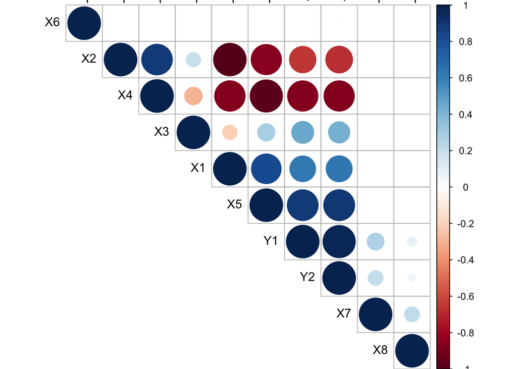

```r
#varibles with p> 0.01 are left blank only significant correlations are shown in color. color intensity is proportional to the correlation coefficient.
#library(corrplot)
res <- cor(EE)
#quartz()
plot1<-corrplot(res, type = "upper", order = "hclust",
         tl.col = "black", tl.srt = 45)
```

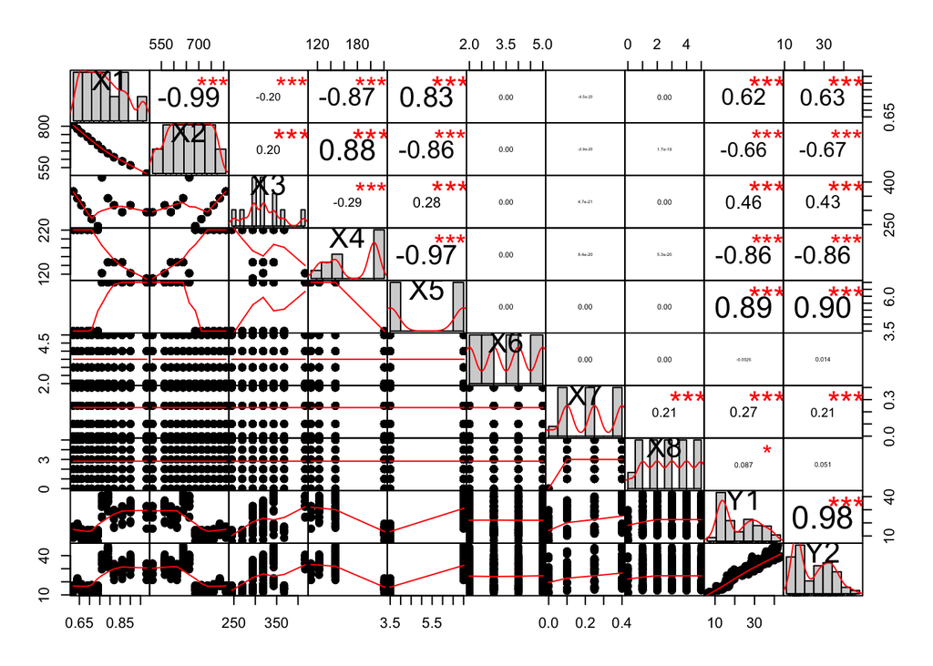

```r
#library(PerformanceAnalytics)
#quartz()
chart.Correlation(EE, histogram=TRUE, pch=19)
```

Next we will create training (60%), CV (20%), and test (20%) datasets

```r
smp_size <- floor(0.6 * nrow(EE))
## set the seed to make your partition reproductible
set.seed(123)
train_ind <- sample(seq_len(nrow(EE)), size = smp_size)
train <- EE[train_ind, ]
split <- EE[-train_ind, ]

smp_size2 <- floor(0.5 * nrow(split))
## set the seed to make your partition reproductible, change seed to get different data partitions
set.seed(123)
train_ind2 <- sample(seq_len(nrow(split)), size = smp_size2)
CV <- split[train_ind2, ]
test <- split[-train_ind2, ]
```

Lets try the Random forest model and look at accuracy of the model for regression predicion

```r
#library(randomForest)
rfreg_Y1 = randomForest(Y1~., data=train[,-10], mtry=3, ntree=100, importance=TRUE,
                      na.action=na.omit, keep.inbag=TRUE, keep.forest=TRUE)
print(rfreg_Y1)
```

```
##
## Call:
##  randomForest(formula = Y1 ~ ., data = train[, -10], mtry = 3,      ntree = 100, importance = TRUE, keep.inbag = TRUE, keep.forest = TRUE,      na.action = na.omit)
##                Type of random forest: regression
##                      Number of trees: 100
## No. of variables tried at each split: 3
##
##           Mean of squared residuals: 0.7138388
##                     % Var explained: 99.28
```

```r
rfpred_Y1<- predict(rfreg_Y1, newdata=CV[,-10])
rfpredictions <- data.table(cbind(CV, rfpred_Y1))
```

Now we can look at varible importance. Normally we want to create the most parsimonious (fewest varibles with best performance) model, however this model is small and managable, so dropping varible is not required.

[figure not shown]

```r
#quartz()
varImpPlot(rfregt1,col="blue",pch= 2)
```

Lets take a look at the yhat for the model and Mean Squared Error

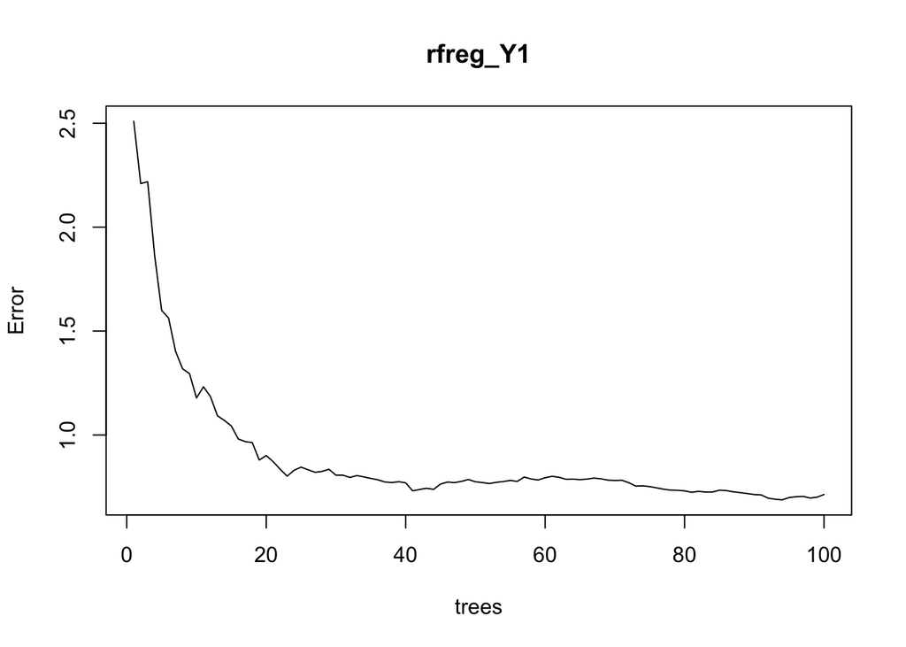

```r
# Plot the error as the number of trees increases
#quartz();
plot(rfreg_Y1)
```

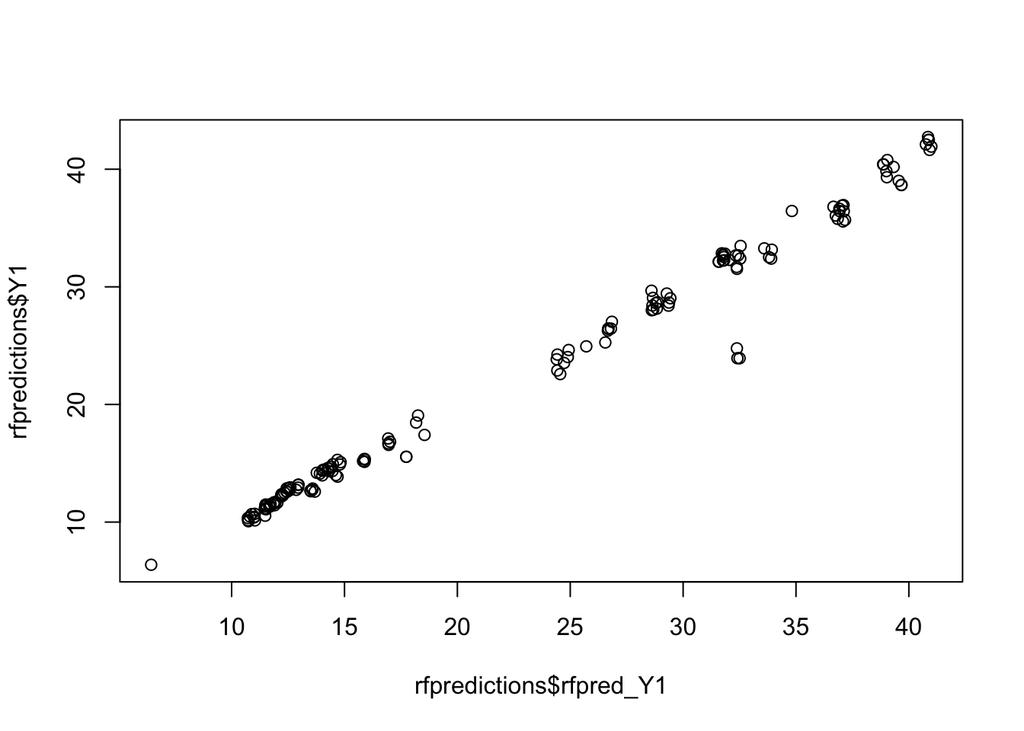

```r
#look at the fit, Y_hat vs. Y1
#quartz()
plot(rfpredictions$rfpred_Y1, rfpredictions$Y1)
```

```r
#Mean Squared Error
mean((rfpredictions$rfpred_Y1-rfpredictions$Y1)^2)
```

```
## [1] 1.888475
```

Now its your turn:

Add code to predict Y2.

Extra fun, set a cutoff value for Y1 and Y2 (lable “efficient”, and “inefficient”), and predict probability of falling above or below the cutoff to create an energry efficient, or energy inefficient building.